# Multiple Regression

## K-Fold Cross-Validation

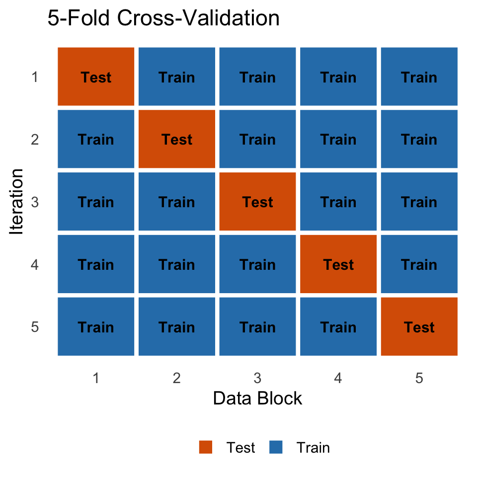

Each row is one iteration: the orange block is held out for testing, the blue blocks are used for training.

## K-Fold Cross-Validation: Example

| Model | CV_MSE |
| --- | --- |
| Authoritarianism only | 0.6143 |
| + Party ID dummies | 0.5890 |

If the fuller model has *lower* CV-MSE, it genuinely improves prediction — not just in-sample fit.

## The Lewis-Beck vs. Achen Debate over $R^2$

Scholars occasionally disgree about the role of $R^2$ in evaluating models.

**Lewis-Beck & Skalaban (1990):** $R^2$ is a useful and informative measure of model fit.

- A high $R^2$ indicates that the model accounts for a substantial share of variance in $Y$
- Comparing $R^2$ across models helps assess whether new predictors contribute
- In applied work, $R^2$ provides a meaningful summary of explanatory power

**Achen (1982, 1990):** $R^2$ is misleading and overemphasized.

- $R^2$ depends on the variance of $X$ in the sample (Remember this calculation?) — the same causal effect can yield very different $R^2$ values in different datasets
- Researchers can inflate $R^2$ by choosing samples with high variance in $X$, or by adding irrelevant predictors
- $R^2$ does not measure *causal* impact; a coefficient’s magnitude, sign, and uncertainty about that estimate matter more

## The Debate: Implications

**Achen’s argument:** is that we should focus attention on *coefficient estimates* and their *standard errors*, not on $R^2$. A model with a small $R^2$ can still identify an important causal effect (e.g., genes and voting); a model with a large $R^2$ can be theoretically vacuous (predictions in small samples).

**Middle Ground:**

- $R^2$ is useful for **prediction** — how well does the model forecast $Y$?
- $R^2$ is less useful for testing substantive theories about variables and their relationships, particularly causal relationships.
- Adjusted $R^2$ and cross-validation are better tools for model comparison than raw $R^2$
- Report $R^2$ but don’t overemphasize it; substantive interpretation of coefficients comes first

## Summary

1. Multiple regression extends OLS to multiple predictors: $\hat{Y} = a + b_1 X_1 + b_2 X_2 + \ldots$
2. Dummy variables encode categorical data as 0/1; omit one category to avoid perfect collinearity
3. The omitted group is the **reference category**; coefficients are differences from it
4. $R^2$ always increases with more predictors; **adjusted $R^2$** penalizes for complexity
5. **Overfitting**: high in-sample $R^2$ does not guarantee good out-of-sample prediction
6. **K-fold cross-validation** estimates true predictive performance by repeatedly holding out data
7. The Lewis-Beck/Achen debate: $R^2$ is useful for prediction, but coefficients matter more for causal inference

[Google Colab Notebook](https://colab.research.google.com/drive/1aqCtyXcZs8Am5fiei5D2XdAmUV0AUYaf?usp=sharing)

## References

- Achen, Christopher H. 1982. *Interpreting and Using Regression*. Sage.
- Achen, Christopher H. 1990. “What Does ‘Explained Variance’ Explain?” *Political Analysis* 2: 173–184.
- Gill, Jeff. 2006. *Essential Mathematics for Political and Social Research*. Cambridge.
- Hastie, Trevor, Robert Tibshirani, and Jerome Friedman. 2009. *The Elements of Statistical Learning*. 2nd ed. Springer.
- Lewis-Beck, Michael S. and Andrew Skalaban. 1990. “The R-Squared: Some Straight Talk.” *Political Analysis* 2: 153–171.
- Moore, Will and David Siegel. 2013. *A Mathematics Course for Political and Social Research*. Princeton.